# Preliminary Project

Using R on Nowcastic Forecasts with Google Trends  
CSJP

# Goal Data

- ‘Motor Vehicle and Part Dealers’ - a report/survey from Census Bureau sent to motor vehicle and parts dealers that asks their current sales
- The preliminary sales data is released 2 weeks after the end of each month

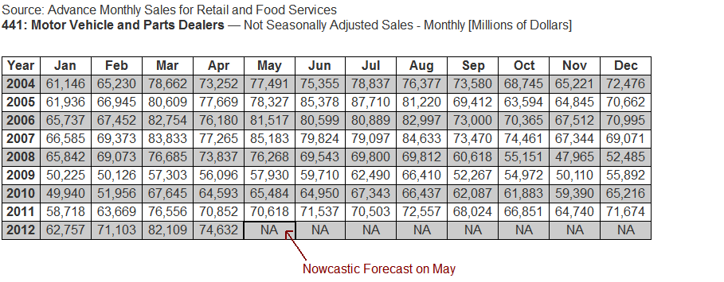

- Nowcastic forecast on May sales with two Google Trends already available on May, 2012

# Collect Data

- Target variable ‘sales’ (Survey Index from Jan. 2004 to Apr. 2012)
- Source: http://www.census.gov/retail/marts/www/timeseries.html

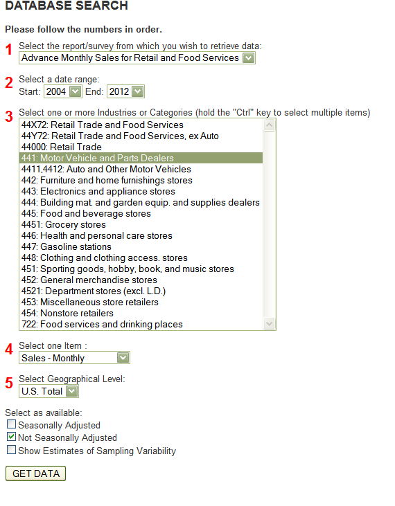

- Predictor ‘tss’ (Query Index - “Trucks + Sedans + SUVs” of Google Trends from Jan. 2004 to May, 2012)
- Source: http://www.google.com/insights/search/

[figure not shown]

- Predictor ‘ins’ (Query Index -“Insurance” of Google Trends from Jan. 2004 to May, 2012)
- Source: http://www.google.com/insights/search/

[figure not shown]

# Analyze Data

- My data set (adt) looks like:

```
##            sales   tss   ins
## 2004-01-01 61146 -0.21 -0.07
## 2004-02-01 65230 -0.28 -0.11
## 2004-03-01 78662 -0.28  0.10
## 2004-04-01 73252 -0.31  0.05
## 2004-05-01 77491 -0.21  0.25
## 2004-06-01 75355 -0.42  0.16
```

- Verify if target variable (sales) is time-correlated:

```
##
##  Box-Ljung test
##
## data:  coredata(adt$sales)
## X-squared = 61.454, df = 1, p-value = 4.552e-15
```

- Yes, then plot it:

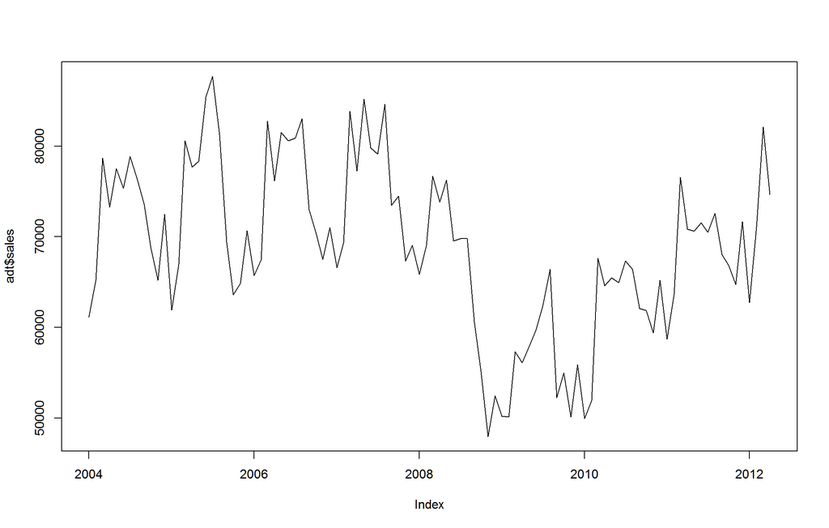

- Since it has large variability, log it, then plot it:

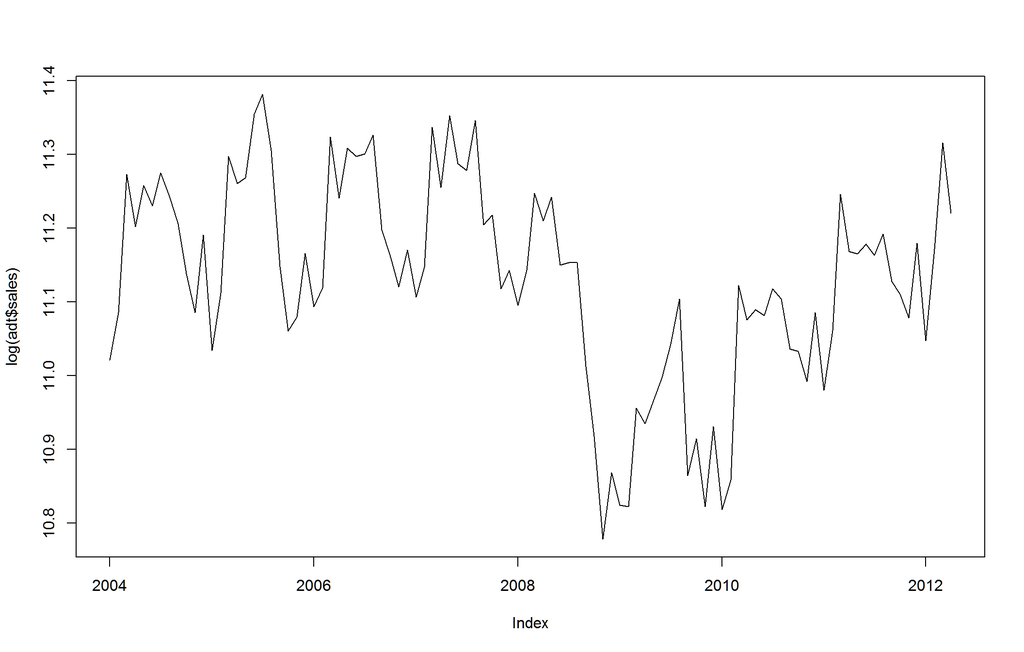

- Diff it and acf/pacf it:

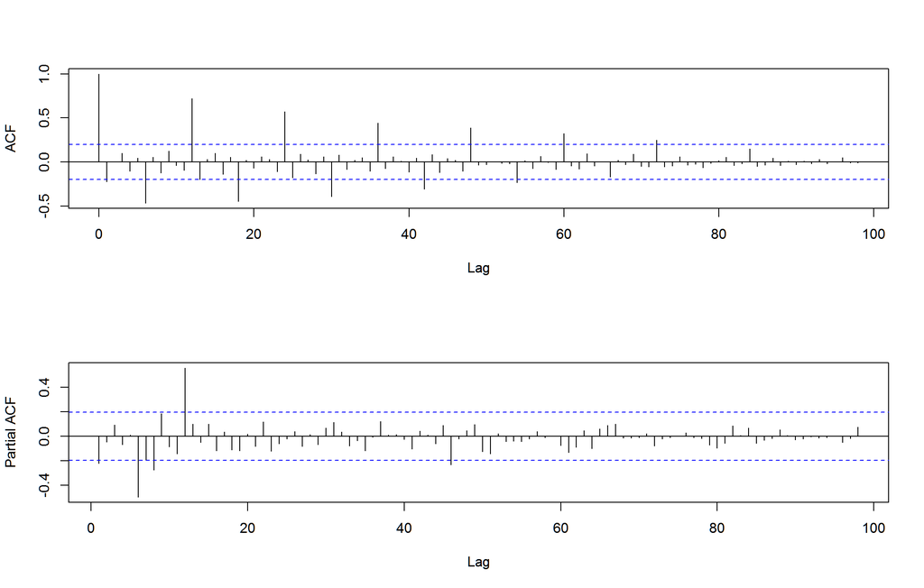

- There is a seasonal component, so diff it by 12, then acf/pacf it:

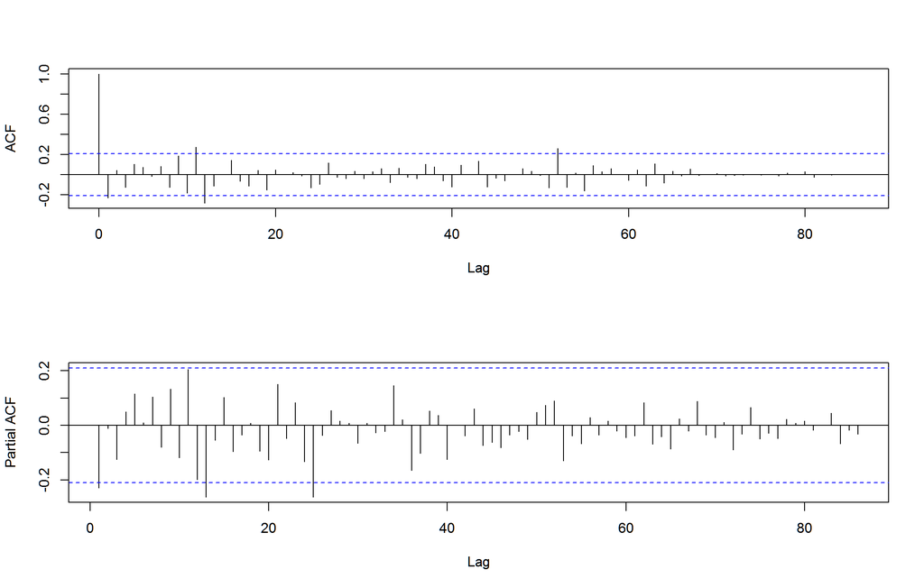

- To sum up - baseline model is a seasonal AR-1 model

# Model Data

- Model 1 - baseline model
- $log(y_t) = a_1log(y_{t-1}) + a_{12}log(y_{t-12}) + e_t$

```
##
## Call:
## lm(formula = y ~ lagy.1 + lagy.12, data = d[-nrow(d), ])
##
## Residuals:
##       Min        1Q    Median        3Q       Max
## -0.213003 -0.038462  0.003142  0.041776  0.218068
##
## Coefficients:
##             Estimate Std. Error t value Pr(>|t|)
## (Intercept)  0.72587    0.75247   0.965    0.337
## lagy.1       0.63737    0.07024   9.074 3.83e-14 ***
## lagy.12      0.29732    0.06923   4.295 4.62e-05 ***
## ---
## Signif. codes:  0 '***' 0.001 '**' 0.01 '*' 0.05 '.' 0.1 ' ' 1
##
## Residual standard error: 0.07979 on 85 degrees of freedom
##   (12 observations deleted due to missingness)
## Multiple R-squared:  0.6991, Adjusted R-squared:  0.692
## F-statistic: 98.75 on 2 and 85 DF,  p-value: < 2.2e-16
```

- Model 2 - baseline model plus two Google Trends
- $log(y_t) = a_1log(y_{t-1}) + a_{12}log(y_{t-12}) +tss+ins+ e_t$

```
##
## Call:
## lm(formula = y ~ ., data = d[-nrow(d), ])
##
## Residuals:
##       Min        1Q    Median        3Q       Max
## -0.166790 -0.044925 -0.002127  0.042199  0.171579
##
## Coefficients:
##             Estimate Std. Error t value Pr(>|t|)
## (Intercept)  2.05232    0.89718   2.288   0.0247 *
## lagy.1       0.54032    0.06656   8.117 3.80e-12 ***
## lagy.12      0.28402    0.06730   4.220 6.20e-05 ***
## tss          0.31692    0.06369   4.976 3.47e-06 ***
## ins          0.36442    0.08657   4.210 6.44e-05 ***
## ---
## Signif. codes:  0 '***' 0.001 '**' 0.01 '*' 0.05 '.' 0.1 ' ' 1
##
## Residual standard error: 0.06924 on 83 degrees of freedom
##   (12 observations deleted due to missingness)
## Multiple R-squared:  0.7787, Adjusted R-squared:  0.7681
## F-statistic: 73.03 on 4 and 83 DF,  p-value: < 2.2e-16
```

- Verify if Model 2 is improved significantly from Model 1:

```
## Analysis of Variance Table
##
## Model 1: y ~ lagy.1 + lagy.12
## Model 2: y ~ lagy.1 + lagy.12 + tss + ins
##   Res.Df     RSS Df Sum of Sq      F    Pr(>F)
## 1     85 0.54115
## 2     83 0.39794  2    0.1432 14.934 2.883e-06 ***
## ---
## Signif. codes:  0 '***' 0.001 '**' 0.01 '*' 0.05 '.' 0.1 ' ' 1
```

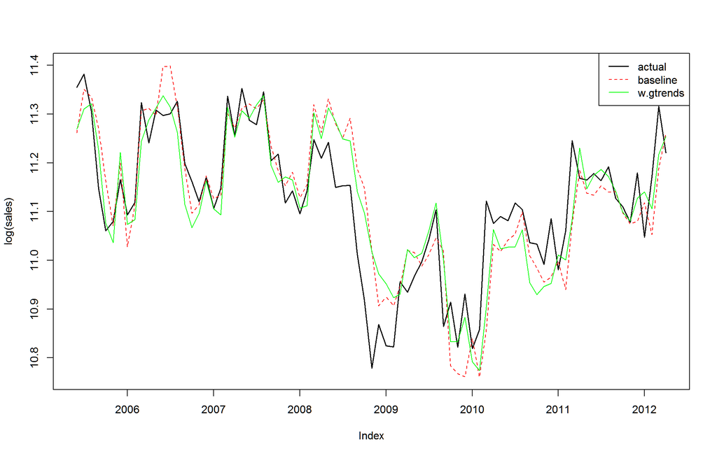

- Evaluate models against normalized mean square errors (NMSE)

```
##     nmse.baseline    nmse.w.gtrends nmse.improved (%)
##         0.3509923         0.2743213        21.8440738
```

- Pick Model 2 to next step

# Forecast Data

- Nowcastic forecast on May sales with Google Trends data available on May, 2012

```
##            sales   tss   ins
## 2011-12-01 71674  0.31 -0.40
## 2012-01-01 62757  0.08 -0.27
## 2012-02-01 71103  0.15 -0.27
## 2012-03-01 82109  0.01 -0.18
## 2012-04-01 74632 -0.03 -0.21
## 2012-05-01    NA -0.04 -0.15
```

- Forecast with prediction intervals

```
##                fit      lwr      upr
## 2012-05-01 74505.7 64817.91 85641.45
```

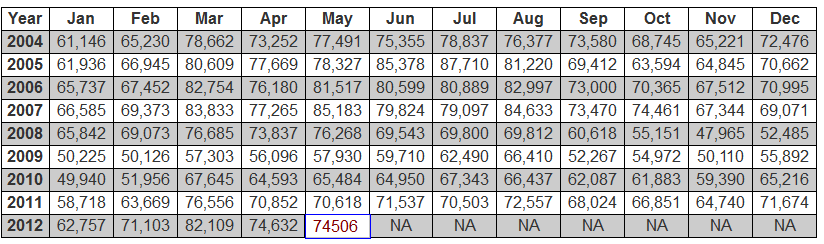

- Done and Pray!